# R Notebook

###Previous Labs (Copied from Github)

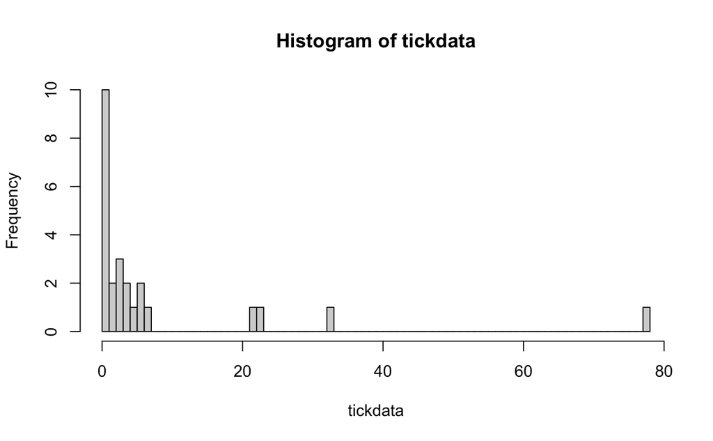

```r
#Data: number of ticks found on dogs sampled from a shelter
tickdata<- c(0,0,0,0,1,0,6,0,3,3,5,22,0,0,3,33,4,2,1,23,7,2,4,6,78)
hist(tickdata, breaks=90)
```

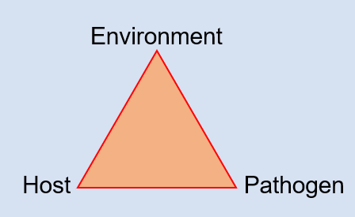

# Lab: Measures of Disease Frequency

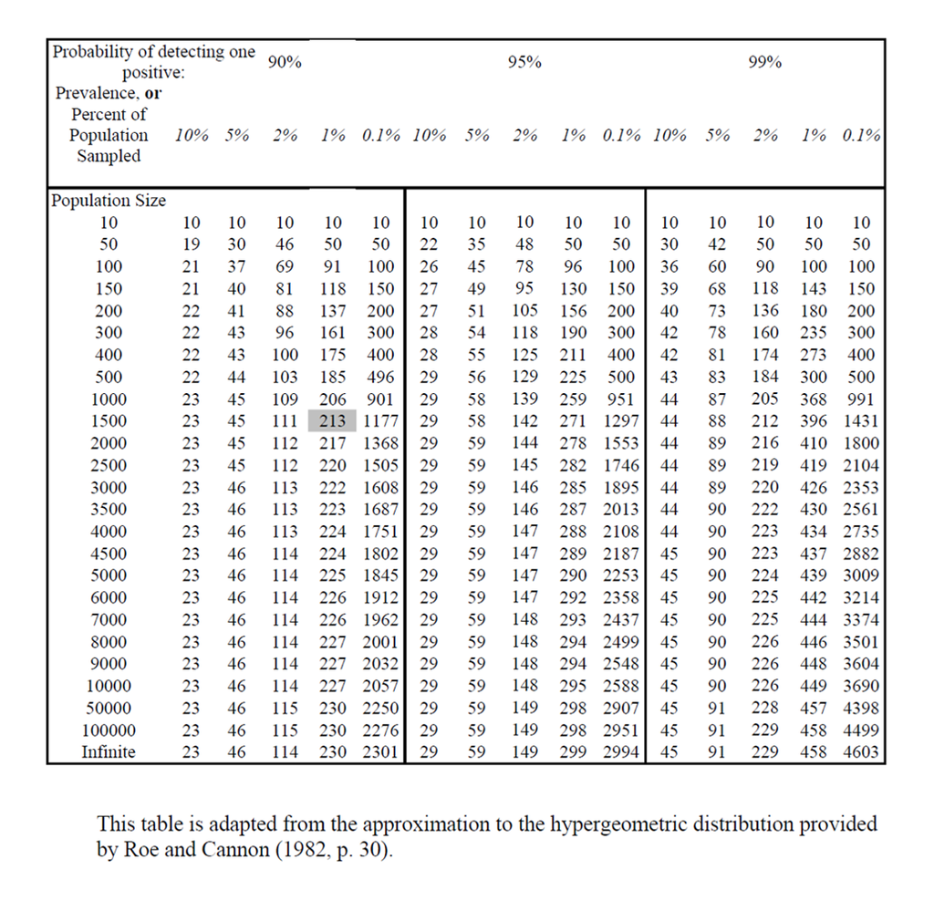

1. The sample size necessary to detect disease at or above 5% prevalence in a herd of 5000 deer at 95% confidence is 59 deer.

2. Hypergeometric distribution
1. The sample size required to detect disease at 1% prevalence in a large population at 95% confidence is around 300
2. The sample size required to detect disease at 2% prevalence in a large population at 99% confidence is around 230 Situation B, despite being measured at a higher confidence, requires a lower sample size than situation A. This is because in a large populations size, the difference between 1% and 2% can be significant.
3. 300 deer sampled out of a population of 4000 tested negative for antibodies against Epizootic Hemorrhagic Disease. Based on this finding, we can be 95% confident that the prevalence of exposure to EHD is less than 1%.
4. ‘Lame Disease’ in wild turkeys
1. Lee County prevalence and confidence intervals (Sterne) Prevalence is 0.200 Lower Confidence Level is 0.143 Upper Confidence Level is 0.273

Chambers County prevalence and confidence intervals (Sterne) Prevalence is 0.267 Lower Confidence Level is 0.131 Upper Confidence Level is 0.449

Russell County prevalence and confidence intervals (Sterne) Prevalence is 0.031 Lower Confidence Level is 0.009 Upper Confidence Level 0.087

###SIR Models

```r
library(deSolve)
## Create an SIR function
sir <- function(time, y, parameters) {   #time, state , parameters

  with(as.list(c(y, parameters)), {

    dS <- -beta * S * I
    dI <-  beta * S * I - gamma * I
    dR <-                 gamma * I
    dN <- dS + dI + dR

    return(list(c(dS, dI, dR, dN)))
  })
}

### Set parameters
## Proportion in each compartment: Susceptible 0.999999, Infected 0.000001, Recovered 0
#init       <- c(S = 1-1e-6, I = 1e-6, R = 0.0)
init <- c(S = 0.99, I = 0.01, R = 0, N = 1)
## beta: infection parameter; gamma: recovery parameter
#parameters <- c(beta = 1.4247, gamma = 0.14286)b=.0952381 g = 0.04761905
parameters <- c(beta = 1, gamma = 1) #gamma=0.1
## Time frame
times      <- seq(0, 300, by = 1)

## Solve using ode (General Solver for Ordinary Differential Equations)
out <- ode(y = init, times = times, func = sir, parms = parameters)
## change to data frame
out <- as.data.frame(out)
## Delete time variable
out$time <- NULL
## Show data
head(out, 10)

## Plot
matplot(x = times, y = out, type = "l",
        xlab = "Time", ylab = "Proportion", main = "SIR Model",
        lwd = 1, lty = 1, bty = "l", col = 1:4)

## Add legend
legend(240, 0.7, c("Susceptible", "Infected", "Recovered", "Total"), pch = 1, col = 1:4, bty = "n")
```

[output not shown]

#Frog Bullying Disease

Gamma = 1/21 = 0.048 If R0 = 2, then Beta = 2*0.048 = 0.096

```r
library(deSolve)
## Create an SIR function
sir <- function(time, y, parameters) {   #time, state , parameters

  with(as.list(c(y, parameters)), {

    dS <- -beta * S * I
    dI <-  beta * S * I - gamma * I
    dR <-                 gamma * I
    dN <- dS + dI + dR

    return(list(c(dS, dI, dR, dN)))
  })
}

### Set parameters
## Proportion in each compartment: Susceptible 0.999999, Infected 0.000001, Recovered 0
#init       <- c(S = 1-1e-6, I = 1e-6, R = 0.0)
init <- c(S = 0.99, I = 0.01, R = 0, N = 1)
## beta: infection parameter; gamma: recovery parameter
#parameters <- c(beta = 1.4247, gamma = 0.14286)b=.0952381 g = 0.04761905
parameters <- c(beta = 0.096, gamma = 0.048) #gamma=0.1
## Time frame
times      <- seq(0, 300, by = 1)

## Solve using ode (General Solver for Ordinary Differential Equations)
out <- ode(y = init, times = times, func = sir, parms = parameters)
## change to data frame
out <- as.data.frame(out)
## Delete time variable
out$time <- NULL
## Show data
head(out, 10)

## Plot
matplot(x = times, y = out, type = "l",
        xlab = "Time", ylab = "Proportion", main = "SIR Model",
        lwd = 1, lty = 1, bty = "l", col = 1:4)

## Add legend
legend(240, 0.7, c("Susceptible", "Infected", "Recovered", "Total"), pch = 1, col = 1:4, bty = "n")
```

[output not shown]

###October 25, 2023 Lab: Disease Distribution Map in R

```r
library(ggplot2)
library(usmap)
library(dplyr)
alhdata<-us_map(regions = "states")
states_found <- c("Virginia","West Virginia","North Carolina", "New Jersey", "Pennsylvania", "New York", "Maryland", "Tennessee", "Kentucky", "Ohio", "Georgia", "Connecticut", "Delaware", "Missouri", "South Carolina", "Arkansas", "Massachusetts", "Rhode Island")
alt_dist<-ggplot(alhdata,aes(x,y,group=group,fill=full%in%states_found))+geom_polygon(color='black')+coord_equal()+scale_fill_manual(values=c('white','firebrick'),guide='none')+usmap:::theme_map()+labs(title="Asian longhorned tick distribution in US states",subtitle="As of February 2023;https://www.cdc.gov/ticks/longhorned-tick/.")+theme(panel.background = element_rect(color = "black", fill = "gray"))
alt_dist
```

[output not shown]

```r
alhdata<-us_map(regions = "states")
states_found <- c("Alabama","Arkansas","Colorado", "Idaho", "Illinois", "Iowa", "Kansas", "Louisiana", "Maryland", "Michigan", "Minnesota", "Mississippi", "Missouri", "Montana", "Nebraska", "New Mexico", "New York", "North Carolina", "North Dakota", "Ohio", "Pennsylvania", "South Dakota", "Tennessee", "Texas", "Utah", "Virginia", "West Virginia", "Wisconsin", "Wyoming")
alt_dist<-ggplot(alhdata,aes(x,y,group=group,fill=full%in%states_found))+geom_polygon(color='black')+coord_equal()+scale_fill_manual(values=c('white','#336633'),guide='none')+usmap:::theme_map()+labs(title="Chronic Wasting Disease distribution in US states",subtitle="As of February 2023;https://www.cdc.gov/prions/cwd/occurrence.html")+theme(panel.background = element_rect(color = "black", fill = "gray"))
alt_dist
```

[output not shown]